# Le Chi 2

s.jaubert

18 décembre 2020

**Référence : l’excellent site d’Antoine Massé https://sites.google.com/site/rgraphiques**

Le $\chi^{2}$ (synonymes X², Chi2, Khi2, Chi², Khi²) permet de comparer des répartitions d’effectifs. On distingue :

le $\chi^{2}$ de conformité qui permet de comparer un effectif (ou une fréquence) à une valeur théorique attendue.

les $\chi^{2}$ d’homogénéité et d’indépendance qui permettent de voir si un effectif peut être dû au seul hasard.

### $\chi^{2}$ de conformité

**Définition du $\chi^{2}$ de conformité**

Le $\chi^{2}$ de conformité permet de savoir s’il y a correspondance entre la théorie et une répartition observée. Le test du $\chi^{2}$ permet donc de voir si un échantillon est conforme à la théorie ou s’il en diffère significativement.

L’hypothèse nulle ($H_{0}$) est : La distribution observée est conforme à la distribution théorique choisie. Le résultat du Chi² de conformité permet de rejeter ou non $H_{0}$ au risque $\alpha$.

**Résultats**

La p-value c’est la probabilité pour un modèle statistique donné **sous l’hypothèse nulle** d’obtenir la même valeur ou une valeur encore plus extrême que celle **observée**.

La p-value donne la probabilité de non-validation de $H_{0}$ plus la p-value est petite, plus la théorie et l’observation diffèrent.[Source](https://sites.google.com/site/rgraphiques/4--stat/comparer-et-%C3%A9tudier-des-effectifs-et-proportions-en-langage-r/test-du-ch2-khi2)

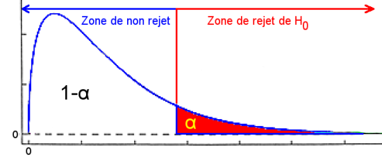

X-square, cette valeur classique renvoyée par un test de Khi2 permet de retrouver manuellement la p-value en s’aidant d’un tableau disponible dans tout bon livre de statistiques (ou outil électronique).

Exemple de $\chi²$ de conformité

On lance 60 fois un dé cubique, d’un point de vue théorique nous devrions obtenir en moyenne 10 “Six” or nous en avons 19 le dé est-il bien équilibré ?

```r
# Descendance observée
observation <- c(19,41)
# probabilités théoriques : d'un point de vue théorique, on devrait avoir 3/4 et 1/4 soit 75 et 25%
proba <- c(1/6,5/6)
# Réalisation du test de khi-deux
test<-chisq.test(observation,p=proba)
test
```

```
##
##  Chi-squared test for given probabilities
##
## data:  observation
## X-squared = 9.72, df = 1, p-value = 0.001823
```

Ainsi, la p-value ici nous permet d’en déduire que les résultats observés ne sont pas conformes à la théorie au risque $\alpha$

Voici en détail ce que donne le résultat du test :

```r
test$statistic #: la statistique du Chi2.
```

```
## X-squared
##      9.72
```

```r
test$parameter #: le nombre de degrés de libertés.
```

```
## df
##  1
```

```r
test$p.value #: la p-value.
```

```
## [1] 0.001822735
```

```r
test$observed #: la matrice observée de départ.
```

```
## [1] 19 41
```

```r
test$expected #: la matrice attendue sous l'hypothèse nulle d'absence de biais.
```

```
## [1] 10 50
```

### $\chi^{2}$ d’indépendance

**Définition du $\chi^{2}$ d’indépendance**

Le $\chi^{2}$ d’indépendance permet de savoir si il y a indépendance entre 2 critères susceptibles de créer une différence de répartition.

L’hypothèse nulle ($H_{0}$) est : le fait de connaître l’appartenance d’un individu à une population (selon un critère) ne donne aucun indice sur la caractéristique qui le défini selon l’autre critère.

Par exemple : est-ce que le fait de connaître la couleur des yeux de quelqu’un me permet de supposer sur son sexe ?

Rèponse : non.

Par exemple : est-ce que le fait de connaître la taille de quelqu’un permet de supposer sur son sexe ? Réponse : oui, plus un individu est petit, plus il y a des chances que ce soit une femme.

Résultats La p-value donne la probabilité de validation de $H_{0}$

Plus la p-value est petite, plus il y a un lien entre les critères (et donc pas d’indépendance).

```r
# Créations des vecteurs correspondant à 2 catégories et pour chaque catégories 4 tranches salariales :
hommes = c(50,70,110,60)
femmes = c(80,75,100,30)
# Création d'une matrice des effectifs comparative :
tableau = matrix(c(hommes, femmes),2,4,byrow=T) # (2 : nombre de lignes et 4 nombres de colonnes (tranches salariales))
tableau
```

```
##      [,1] [,2] [,3] [,4]
## [1,]   50   70  110   60
## [2,]   80   75  100   30
```

```r
# Réalisation du test khi-deux - les résultats sont sauvegardés dans "khi_test"
test = chisq.test(tableau)
test # affiche le résultat du test
```

```
##
##  Pearson's Chi-squared test
##
## data:  tableau
## X-squared = 17.53, df = 3, p-value = 0.0005499
```

Ainsi, la p-value ici est de 0.0005 : il y a donc un lien statistique entre le sexe et la tranche salariale car la p-value est très petite.

De même nous avons :

```r
test$statistic #: la statistique du Chi2.
```

```
## X-squared
##  17.52953
```

```r
test$parameter #: le nombre de degrés de libertés.
```

```
## df
##  3
```

```r
test$p.value #: la p-value.
```

```
## [1] 0.0005498866
```

```r
test$observed #: la matrice observée de départ.
```

```
##      [,1] [,2] [,3] [,4]
## [1,]   50   70  110   60
## [2,]   80   75  100   30
```

```r
test$expected #: la matrice attendue sous l'hypothèse nulle d'absence de biais.
```

```
##          [,1]     [,2]    [,3]    [,4]
## [1,] 65.56522 73.13043 105.913 45.3913
## [2,] 64.43478 71.86957 104.087 44.6087
```

### $\chi^{2}$ d’homogénéité

Le $\chi^{2}$ d’homogénéité est un $\chi^{2}$ d’indépendance. Il est seulement réalisé dans un but différent.

Le $\chi^{2}$ d’homogénéité permet de vérifier que les répartitions de différents effectifs sont équivalentes.

Ce test repose ainsi sur 2 hypothèses :

- $H_{0}$ : il n’y a pas de différence significative dans la répartition des groupes étudiés
- $H_{1}$ : il y a une différence - cette hypothèse est a affiner en fonction du cas étudié (cf. exemple ci-dessous)

```r
# Créations des vecteurs correspondant aux 2 catégories :
pedago1 = c(51, 29)
pedago2 = c(38, 12)
pedago3 = c(86, 34)
# Création d'une matrice comparative :
tableau = matrix(c(pedago1,pedago2,pedago3),3,2,byrow=T)
colnames(tableau)<-c("Reçus","recalés")
tableau
```

```
##      Reçus recalés
## [1,]    51      29
## [2,]    38      12
## [3,]    86      34
```

```r
# (3 : nombre de lignes et 2 nombres de colonnes)

# autre méthode
tableau = rbind(pedago1,pedago2,pedago3)
colnames(tableau)<-c("Reçus","recalés")
tableau
```

```
##         Reçus recalés
## pedago1    51      29
## pedago2    38      12
## pedago3    86      34
```

```r
# Réalisation du test khi-deux - les résultats sont sauvegardés dans "khi_test"
test = chisq.test(tableau)
test # affiche le r?sultat du test
```

```
##
##  Pearson's Chi-squared test
##
## data:  tableau
## X-squared = 2.504, df = 2, p-value = 0.2859
```

La p-value n’est pas suffisament petite on ne peut rejeter $H_{0}$

```r
test$statistic #: la statistique du Chi2.
```

```
## X-squared
##  2.503968
```

```r
test$parameter #: le nombre de degrés de libertés.
```

```
## df
##  2
```

```r
test$p.value #: la p-value.
```

```
## [1] 0.2859369
```

```r
test$observed #: la matrice observée de départ.
```

```
##         Reçus recalés
## pedago1    51      29
## pedago2    38      12
## pedago3    86      34
```

```r
test$expected #: la matrice attendue sous l'hypothèse nulle d'absence de biais.
```

```
##         Reçus recalés
## pedago1    56      24
## pedago2    35      15
## pedago3    84      36
```

**un exemple avec un tableau de contingence**

```r
###########################################################################################
#Tableau de Contingence

tableau<-matrix(c(1768,807,189,47,946,1387,746,53,115,438,288,16),ncol = 4,byrow = T)
tableau
```

```
##      [,1] [,2] [,3] [,4]
## [1,] 1768  807  189   47
## [2,]  946 1387  746   53
## [3,]  115  438  288   16
```

```r
rownames(tableau)<-c("bleu","gris ou vert","marron")
colnames(tableau)<-c("blond","chatain","noir","roux")
tableau
```

```
##              blond chatain noir roux
## bleu          1768     807  189   47
## gris ou vert   946    1387  746   53
## marron         115     438  288   16
```

```r
ni.<-margin.table(tableau,1)
ni.
```

```
##         bleu gris ou vert       marron
##         2811         3132          857
```

```r
n.j<-margin.table(tableau,2)
n.j
```

```
##   blond chatain    noir    roux
##    2829    2632    1223     116
```

```r
sum(ni.)
```

```
## [1] 6800
```

```r
sum(n.j)
```

```
## [1] 6800
```

```r
n..<-sum(ni.)
n..
```

```
## [1] 6800
```

```r
addmargins(tableau)
```

```
##              blond chatain noir roux  Sum
## bleu          1768     807  189   47 2811
## gris ou vert   946    1387  746   53 3132
## marron         115     438  288   16  857
## Sum           2829    2632 1223  116 6800
```

```r
(freqabs<-round(tableau/n..*100,2))
```

```
##              blond chatain  noir roux
## bleu         26.00   11.87  2.78 0.69
## gris ou vert 13.91   20.40 10.97 0.78
## marron        1.69    6.44  4.24 0.24
```

```r
test<-chisq.test(tableau)
test$statistic #: la statistique du Chi2.
```

```
## X-squared
##  1073.508
```

```r
test$parameter #: le nombre de degrés de libertés.
```

```
## df
##  6
```

```r
test$p.value #: la p-value.
```

```
## [1] 1.124431e-228
```

```r
addmargins(test$observed) #: la matrice observée de départ.
```

```
##              blond chatain noir roux  Sum
## bleu          1768     807  189   47 2811
## gris ou vert   946    1387  746   53 3132
## marron         115     438  288   16  857
## Sum           2829    2632 1223  116 6800
```

```r
addmargins(test$expected) #: la matrice attendue sous l'hypothèse nulle d'absence de biais.
```

```
##                  blond   chatain      noir      roux  Sum
## bleu         1169.4587 1088.0224  505.5666  47.95235 2811
## gris ou vert 1303.0041 1212.2682  563.2994  53.42824 3132
## marron        356.5372  331.7094  154.1340  14.61941  857
## Sum          2829.0000 2632.0000 1223.0000 116.00000 6800
```

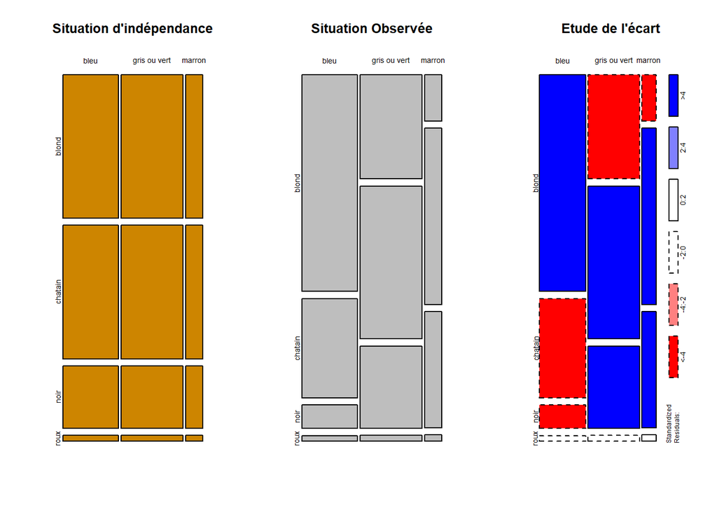

```r
par(mfrow=c(1,3))
mosaicplot(test$expected, main="Situation d'indépendance", col="orange3")
mosaicplot(tableau, main="Situation Observée")
mosaicplot(tableau, shade=TRUE, main="Etude de l'écart")
```